# Implementation of Vaccines Against Invasive Meningococcal Disease (IMD) within the National Immunisation Program (NIP)

Project 3

# 1 Recommendation for Dr Masha Somi, Chair of the [National Immunisation Committee (NIC)](https://www.health.gov.au/committees-and-groups/national-immunisation-committee)

## 1.1 Client Bio

[Dr Somi](https://www.directory.gov.au/people/masha-somi) is the Chair of the NIC and is interested in vaccination efficacy against Meningococcal to justify the NIP.

## 1.2 Recommendation

To effectively combat against Meningococcal, it is recommended to provide the Bexsero and Menveo vaccines through the National Immunisation Program at the youngest (medically appropriate) age. However, a clinical trial should be explored to provide more data on vaccine efficacies.

# 2 Evidence

```r
## Initialise Libraries
library(ggplot2)
library(plotly)
library(tidyverse)
library(leaflet)
library(leaflet.extras)
library(readxl)
library(dplyr)
library(readr)
library(geosphere)
library(knitr)
library(scales)
library(lubridate)
library(wesanderson)
```

```r
# Read in the dataset
disease = read.csv("http://www.maths.usyd.edu.au/u/UG/JM/DATA1001/r/current/projects/2022data/disease.csv")

# Vector that stores the columns that will be converted to numeric values
to_numeric <- c("TotalVacc",
                "MencevaxACWY",
                "Menomune",
                "Meningitec",
                "Menugate",
                "NeisVac.C",
                "Bexsero",
                "Menactra",
                "Menveo",
                "Menitorix",
                "VaccTypeUnknown")

# Vector that stores the columns that will be converted to factor values
to_factor <- c("State",
               "Serogroup",
               "AgeGroup",
               "Sex",
               "IndigStatus",
               "VaccStatus")

# Defines a one_sided function to set NaN values to equal 0
replace_na_one_sided <- function(col){
  replace_na(col, 0)
}

# Data cleaning and mutation of the columns into desired type
disease <- disease %>%
  mutate(Month.1 = str_trim(Month.1)) %>%   # Creates columns used to generates the dates of when a case was detected
  mutate(Month.1 = match(Month.1, month.name)) %>%
  mutate(Day = 1) %>%
  unite(Date, c('Month', 'Month.1', 'Day'), sep = "-") %>%
  mutate(Date = as.Date(Date)) %>%
  separate(col = Date, into = c('Year', 'Month', 'Day'),
           sep = '-',
           convert = TRUE,
           remove = FALSE) %>%
  mutate(Quater = ceiling(Month / 3)) %>%
  mutate(Year.as.decimal = (as.numeric(Year) +
                            as.numeric(Quater)*.25)) %>%

  mutate_at(to_numeric, as.numeric) %>%   # Converts the columns in to_numeric into numeric columns
  mutate_at(to_numeric, replace_na_one_sided) %>%

  mutate_at(to_factor, as.factor)# Converts the columns in to_factor into factor columns

# Refactorises the Serogroup column
disease$Serogroup <- fct_rev(
  recode_factor(disease$Serogroup,
                B = "MenB",
                W = "MenW",
                Y = "MenY",
                C = "MenC",
                UNKNOWN = "Unknown"))
```

## 2.1 Context

The [Invasive Meningococcal Disease (IMD) Public Data Set](https://www.health.gov.au/resources/publications/nndss-public-dataset-meningococcal-disease-invasive) (2022) provides notification data of cases caused by IMD, extracted from the [NNDSS](https://www.health.gov.au/initiatives-and-programs/nndss) between 2009 and 2019. This data was used to access the relative efficacy of vaccines against the four main serogroups of Meningococcal. However, it is important to note that this is only a sample of total cases of IMD in Australia ([National Notifiable Diseases Surveillance System, 2022](https://www.health.gov.au/sites/default/files/documents/2022/09/national-notifiable-diseases-surveillance-system-nndss-public-dataset-meningococcal-disease-invasive-caveats.pdf)). Without a clinical trial, the efficacy of each vaccine can only be estimated from this dataset. Hence, a randomized double-blind placebo-control study should be explored to further justify this recommendation.

## 2.2 Overall Vaccine Efficacy Analysis

Despite the low percentage of non-vaccinated individuals, they comprise the majority of IMD cases.

From the dataset, 61% of cases came from non-vaccinated individuals. This high percentage is concerning, given the high vaccination rates against Meningococcal within Australia. The disease is currently part for the NIP with “95% of Australian 2-year-olds were vaccinated against meningococcal C” ([Australian Institute of Heath and Welfare, 2018, p.p 1](https://www.aihw.gov.au/getmedia/17aa17bf-d061-41e2-9655-16a1cdcc8512/aihw-phe-236_Meningococcal.pdf.aspx)). This shows the efficacy of vaccines as a whole.

## 2.3 Serogroup Analysis

The prevalence of Meningococcal’s serogroups changed within the 10-year collection period.

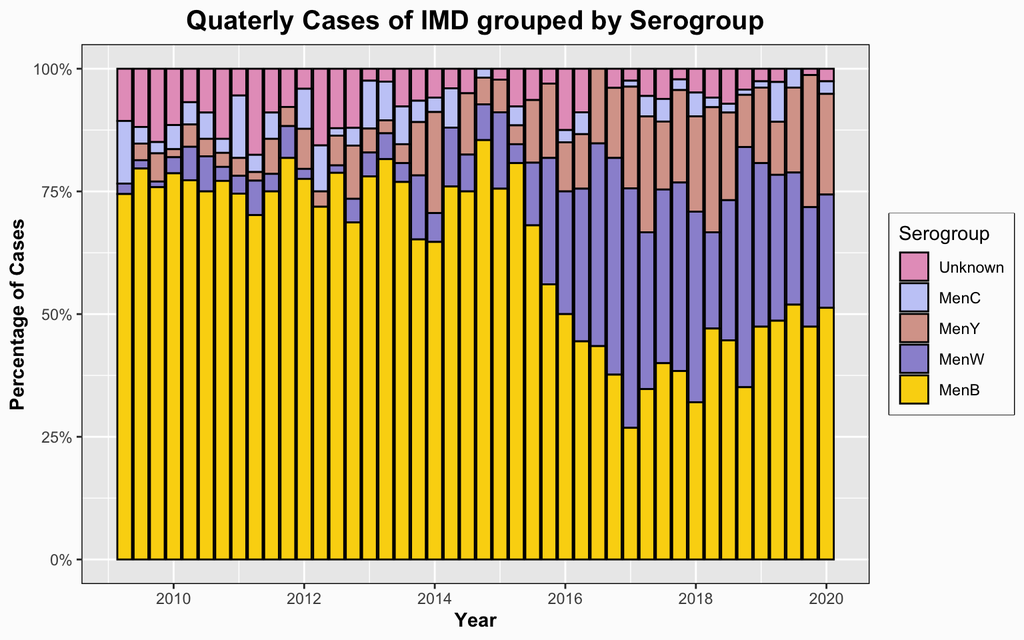

Figure 1: Proportion Bar Chart of the Quarterly Cases of IMD grouped by Serogroup.

```r
# Production of the first chart
disease %>%
  ggplot(aes(x=Year.as.decimal, #Sets the year as the x-axis and fill type by Serogroup
             fill=Serogroup)) +

  geom_bar(colour = "black", #Creates a proportion bar chart
           size = 0.5,
           position = "fill") +

  labs(y="Proportion of Cases", #Changes the axis label and title
       x="Year",
       title="Quaterly Cases of IMD grouped by Serogroup",) +

  theme(plot.background = element_rect(fill = "#fcfcfc", #Changes the aesthetics of the chart
                                       size = 0),
        legend.background = element_rect(fill = "#fcfcfc",
                                       size = 0),
        panel.border = element_rect(colour = "black", fill=NA),
        legend.box.background = element_rect(colour = "black"),
        axis.title = element_text(face="bold"),
        plot.title = element_text(face="bold",
                                  size = 15,
                                  hjust = 0.5)) +

  scale_fill_manual(values = c(rgb(230/255,160/255,196/255), #Sets the fill colours of the Serogroups
                               rgb(198/255,205/255,247/255),
                               rgb(216/255,164/255,153/255),
                               rgb(155/255,148/255,212/255),
                               rgb(250/255, 213/255, 15/255))) +

  scale_y_continuous(name = "Percentage of Cases", #Changes tick marking to percentage rather than decimal
                     breaks = c(0, 0.25, 0.5, 0.75, 1),
                     labels = c("0%", "25%", "50%", "75%", "100%")) +

  scale_x_continuous(name = "Year",
                    breaks = c(2010, 2012, 2014, 2016, 2018, 2020),
                    labels = c("2010", "2012", "2014", "2016", "2018", "2020"))
```

*Figure 1* shows that *MenB* was the most active serogroup within Australia, contributing 59% of total cases. Moreover, the *MenW* and *MenY* serogroups have become increasingly active, contributing 36% and 18% of cases since 2016 respectively. As such, vaccines recommended in the NIP should protect against these three serogroups at a minimum.

### 2.3.1 MenB

The only vaccine in this dataset that protects against *MenB* is the Bexsero vaccine ([National Notifiable Diseases Surveillance System, 2022](https://www.health.gov.au/sites/default/files/documents/2022/09/national-notifiable-diseases-surveillance-system-nndss-public-dataset-meningococcal-disease-invasive-caveats.pdf)). This vaccine has been approved by the Theraputic Goods Administration ([TGA, 2013](https://www.tga.gov.au/resources/artg/190718)) for infants older than 2 months ([BEXSERO, 2021](https://www.ebs.tga.gov.au/ebs/picmi/picmirepository.nsf/pdf?OpenAgent=&id=CP-2014-CMI-01517-1&d=20221010172310101)). This is why it has been recommended.

### 2.3.2 MenW, MenY and MenC

The other recommended vaccine is the Menveo vaccine, which protects against the other three serogroups ([National Notifiable Diseases Surveillance System, 2022](https://www.health.gov.au/sites/default/files/documents/2022/09/national-notifiable-diseases-surveillance-system-nndss-public-dataset-meningococcal-disease-invasive-caveats.pdf)). One reason for this is 0 cases were seen in the dataset when vaccinated with Menveo. The only other a vaccine that had this attribute of no cases was Menomune. One reason why Menveo has been recommended over Menomune is that Menomune is only TGA approved from 2 years old ([TGA, 2018, p.p. 7](https://www.tga.gov.au/sites/default/files/auspar-menveo-180410.pdf)), compared to Menveo being approved from 2 months ([TGA, 2018, p.p. 6](https://www.tga.gov.au/sites/default/files/auspar-menveo-180410.pdf)), and “MENVEO continued to be statistically higher than Menomune” ([TGA, 2017, p.p. 8](https://www.tga.gov.au/sites/default/files/auspar-menveo-180410-pi.docx)) at protecting against IMD.

## 2.4 Age Analysis

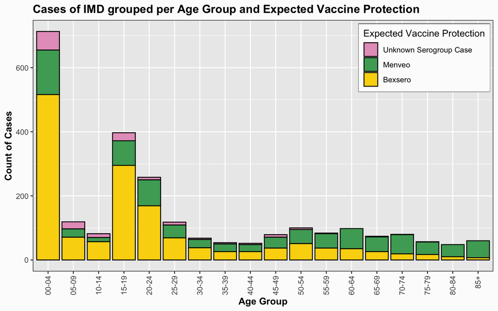

Figure 2: Stacked Bar Chart Depicting Aged-Based IMD Cases Grouped by Expected Vaccine Protection.

```r
#Creates new column that represents which vaccine would have protected against the case
disease <- disease %>%
  mutate(VaccineProtection  = case_when(Serogroup == "MenB" ~ "Bexsero",
                                        Serogroup == "MenC" ~ "Menveo",
                                        Serogroup == "MenY" ~ "Menveo",
                                        Serogroup == "MenW" ~ "Menveo",
                                        Serogroup == "Unknown" ~ "Unknow_Serogroup_Case"))

# Refactorises the VaccineProtection column
disease$VaccineProtection <- fct_rev(
  recode_factor(disease$VaccineProtection,
                Bexsero = "Bexsero",
                Menveo = "Menveo",
                Unknow_Serogroup_Case = "Unknown Serogroup Case"))

# Generates the second chart
disease %>%
  ggplot(aes(x=AgeGroup, fill=VaccineProtection)) + #Sets the age group as the x-axis and fill type by which vaccine would have protected agaisnt the case
  geom_bar(colour = "black", #Creates a bar chart
           size = 0.5) +
  labs(y="Count of Cases", #Changes the axis label and title
       x="Age Group",
       title="Cases of IMD grouped per Age Group and Expected Vaccine Protection") +

  theme(plot.background = element_rect(fill = "#fcfcfc", #Changes the aesthetics of the chart
                                       size = 0),
        legend.background = element_rect(fill = "#fcfcfc",
                                       size = 0),
        panel.border = element_rect(colour = "black", fill=NA),
        legend.box.background = element_rect(colour = "black"),
        axis.title = element_text(face="bold"),
        plot.title = element_text(face="bold"),
        axis.text.x = element_text(angle = 90,hjust=1,vjust=0.5),
        legend.position = c(0.85,0.85)) +

  scale_fill_manual(values = c(rgb(230/255,160/255,196/255), #Sets the fill colours of the Vaccines
                               "#4CA864",
                               rgb(250/255, 213/255, 15/255)),
                    name="Expected Vaccine Protection")
```

As per *Figure 2*, the age group of four years and younger contributed 28% of total cases despite comprising 6% of the population ([Informed Decisions, 2021](https://profile.id.com.au/australia/five-year-age-groups)). This shows the importance of getting vaccinated as early as possible.

## 2.5 Conclusion

All cases with a known Serogroup would have been protected by either Menveo or Bexsero. This is why these vaccines have been recommended.

*Word Count: 399*

# 3 Acknowledgments

I would like to acknowledge my tutors Emily and Eugene for their help with the project.

## 3.1 References

Australian Government Department of Heath and Aged Care Therapeutic Goods Administration (2013, August 14). *BEXSERO - multi-component Meningococcal B vaccine (recombinant, adsorbed) suspension for injection 0.5 ml pre-filled syringe without needle (190718)*. https://www.tga.gov.au/resources/artg/190718

Australian Government Department of Heath and Aged Care (2022, June 20). *National Immunisation Committee*. https://www.health.gov.au/committees-and-groups/national-immunisation-committee

Australian Government Department of Heath and Aged Care (2022, September 26). *National Notifiable Diseases Surveillance System (NNDSS) public dataset – meningococcal disease (invasive)*. https://www.health.gov.au/resources/publications/nndss-public-dataset-meningococcal-disease-invasive

Australian Government Directory (2021, November 19). *Ms. Masha Somi*. https://www.directory.gov.au/people/masha-somi

Australian Institute of Heath and Welfare (2018). *Meningococcal disease in Australia*. https://www.aihw.gov.au/getmedia/17aa17bf-d061-41e2-9655-16a1cdcc8512/aihw-phe-236_Meningococcal.pdf.aspx

BEXSERO (2021, 13 August). *Multicomponent Meningococcal group B vaccine (recombinant, adsorbed) Consumer Medicine Information*. Therapeutic Goods Administration. https://www.ebs.tga.gov.au/ebs/picmi/picmirepository.nsf/pdf?OpenAgent=&id=CP-2014-CMI-01517-1&d=20221010172310101&d=20221021172310101

Informed Decisions (2021). *Australia*. https://profile.id.com.au/australia/five-year-age-groups

National Notifiable Diseases Surveillance System (2022). *Meningococcal Disease (invasive) Public Data Set 2009 to 2021*. https://www.health.gov.au/sites/default/files/documents/2022/09/national-notifiable-diseases-surveillance-system-nndss-public-dataset-meningococcal-disease-invasive-caveats.pdf

Therapeutic Goods Administration (2018, April). *Australian Public Assessment Report for Meningococcal (Groups A, C, W135 and Y) oligosaccharide CRM197 conjugate vaccine*. https://www.tga.gov.au/sites/default/files/auspar-menveo-180410.pdf

Therapeutic Goods Administration (2017, July 3). *Product information for AusPAR Menveo Meningococcal (Groups A,C,W-135 and Y) oligosaccharide CRM197 conjugate vaccine GlaxoSmithKline Australia Pty Ltd PM-2017-00536-1-2*. https://www.tga.gov.au/sites/default/files/auspar-menveo-180410-pi.docx

# 4 Appendix: Defense of Approach

## 4.1 Client

Dr Somi was my chosen Client as she is the Chair of the National Immunisation Committee, which decides on the recommendations of vaccines at a national level.

## 4.2 Statistical Analysis

I used percentages and counts as analysis because they are simple and effective ways to communicate to the Client. The two charts I produced were also easily digestible to the Client, with a common colour theme for related quantities providing continuity in the report and video. I decided against hypothesis testing as the data was limited and my recommendation was to explore a clinical trial, where hypothesis testing would be more appropriate.